# A population analogue of the porous media equation

We’d like to do an analogue of
$$\partial_t n(t, x) = \partial_x^2 \left(n(t, x)^2\right) + n(t,x) (1 - n(t, x)) .$$
To do this, if the death, birth, and establishment rates are $\mu$, $\gamma$, and $r$ respectively, since
$$\partial_t n(t, x) = r(x, t) \partial_x^2 \left(\gamma(x, t) n(t, x)\right) + n(t,x) \left(\gamma(x, t) - \mu(x, t)\right) ,$$
we’ll set $r(x, t) = 1$, and rescale by carrying capacity so that $n(x, t) = N(x, t) / K$, and so if $\gamma = n = N / K$ and $\mu = 2 n - 1 = 2 N / K - 1$ then this is
$$\partial_t N(t, x) = \partial_x^2 \left(\gamma(x, t) N(t, x) \right) + N(t,x) \left(\gamma(x, t) - \mu(x, t)\right) .$$
To check: at equilibrium, $\mu = \gamma$, which happens when $N = K$.

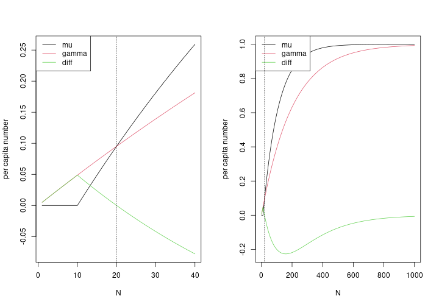

```r
dt <- 0.1
K <- 20
mu <- function (N, K) { pmax(0, pmin(1, 1 - exp(-dt * (2 * N / K - 1)))) }
gamma <- function (N, K) { pmax(0, pmin(1, 1 - exp(-dt * N / K ))) }
layout(t(1:2))
for (max_N in c(40, 1000)) {
    x <- data.frame(N=1:max_N)
    x$mu <- mu(x$N, K)
    x$gamma <- gamma(x$N, K)
    x$diff <- x$gamma - x$mu
    matplot(x$N, as.matrix(x[,c('mu', 'gamma', 'diff')]), type='l', lty=1,
            xlab='N', ylab='per capita number')
    legend('topleft', lty=1, col=1:3, legend=c('mu', 'gamma', 'diff'))
    abline(v=K, lty=3)
}
```

Each individual:

1. produces a single offspring with probability $1 - exp(-dt \gamma)$, and then
2. dies with probability $1 - \exp(-dt \mu)$.

*Note:* at first we had offspring number equal to $dt \gamma$; but this produces unstable populations at large $N$, so now “reproduction of a single offspring happens at rate $\gamma$, but only once per time step”, like death.

So, the average net contribution to the next generation per capita is
$$\begin{aligned}
1 - e^{-dt \gamma} + e^{-dt \mu}
&=
1 - e^{-dt N/K} + e^{-dt (2 N / K - 1)}
\end{aligned}$$
At $N=K$ this is stable, since this is equal to:
$$\begin{aligned}
1 - e^{-dt} + e^{-dt} = 1
\end{aligned}$$

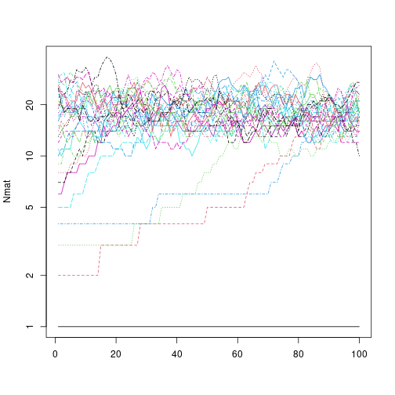

```r
next_gen <- function(N, K) {
    offspring <- rbinom(length(N), size=N, prob=gamma(N, K))
    survivors <- rbinom(length(N), size=N, prob=1 - mu(N, K))
    return(offspring + survivors)
}
Nmat <- matrix(NA, nrow=100, ncol=30)
Nmat[1,] <- 1:ncol(Nmat)
for (k in 2:nrow(Nmat)) {
    Nmat[k, ] <- next_gen(Nmat[k-1,], K)
}
matplot(Nmat, type='l', log='y')
```